# Part II - (Ford GO BIKE)

## by Khalil MISBAH

## Investigation Overview

> The Ford Gobike dataset and subsequent studies revealed a number of intriguing facts about the distribution of bike journeys taken within the chosen time period. Explorations of these links have allowed me to see how seniors enjoy their journeys; primarily not sharing; how much time they spend on excursions; not particularly long; and to respond to other questions.

## Dataset Overview

> The present document examines a dataset that includes roughly 183,412 trips from a Ford GoBike. This data collection contains details on each ride taken in a bike-sharing programme that serves the greater San Francisco Bay area.

## (Visualization 1)

> Bike trips duration follows anormal trend, with riders subscribing for travels of an average period of about 12 min

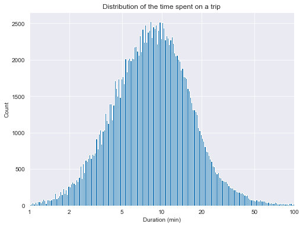

## (Visualization 2)

> Folks with age range between 25 and 35 years are considerend very frequent bike riders, with the most duration estimation of 5 and 20 minute time window.

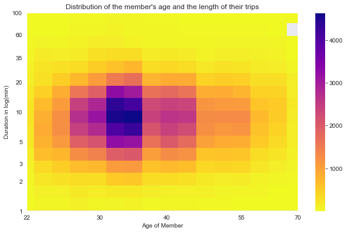

## (Visualization 3)

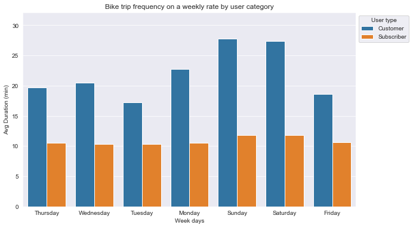